# Reproducible Research

## Peer Assessment 1

### Libraries needed for this asignment.

```r
library(lattice)
```

## Loading and preprocessing the data

### 1. Loads activity data for analysis.

```r
activityData <- read.csv("activity.csv", stringsAsFactors = FALSE)
```

### 2. Performs pre-processing of activity data for usability in the subsequent analysis.

```r
totalStepsDate <- aggregate(steps ~ date, activityData, sum, na.rm = TRUE)
avgStepsInterval <- aggregate(steps ~ interval, activityData, mean, na.rm = TRUE)
maxStepsCount <- which.max(avgStepsInterval$steps)
```

## What is mean total number of steps taken per day?

### 1. A histogram of the total number of steps taken each day.

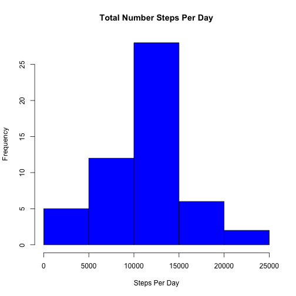

```r
hist(totalStepsDate$steps, col = "blue", main = "Total Number Steps Per Day",
    xlab = "Steps Per Day")
```

### 2. Calculates and reports the mean and median step counts.

```r
meanStepsDay <- mean(totalStepsDate$steps)
medianStepsDay <- median(totalStepsDate$steps)
```

The Mean steps is 1.0766 × 10<sup>4</sup>. The Median steps is 10765.

## What is the average daily activity pattern?

### 1. A time series plot demonstrating a 5 minute interval of the average steps taken across all days.

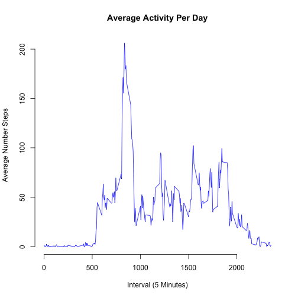

```r
plot(avgStepsInterval$interval, avgStepsInterval$steps, type = "l", frame = FALSE,
    col = "blue", main = "Average Activity Per Day", xlab = "Interval (5 Minutes)",
    ylab = "Average Number Steps")
```

### 2. The interval, on average across all days, with the maximum number of steps.

```r
maxStepsInterval <- avgStepsInterval[maxStepsCount, ]$interval
```

Interval 835 has the most steps.

## Imputing missing values

### 1. Calculates and reports the number of missing values in the dataset

```r
missingValuesTotal <- sum(is.na(activityData$steps))
```

A total of 2304 missing values exist in the dataset.

### 2. & 3. The strategy for filling in missing values in the dataset. Loop through a copy of the dataset looking for missing step values. When found, replace the missing step value with the average number of steps for the matching interval.

```r
activityDataComplete <- activityData
activityCount = 0
for (i in 1:nrow(activityDataComplete)) {
    if (is.na(activityDataComplete[i, ]$steps)) {
        activityDataComplete[i, ]$steps <- avgStepsInterval[avgStepsInterval$interval ==
            activityDataComplete[i, ]$interval, ]$steps
        activityCount <- activityCount + 1
    }
}
```

### 4. The same histogram as above, this time using the complete dataset.

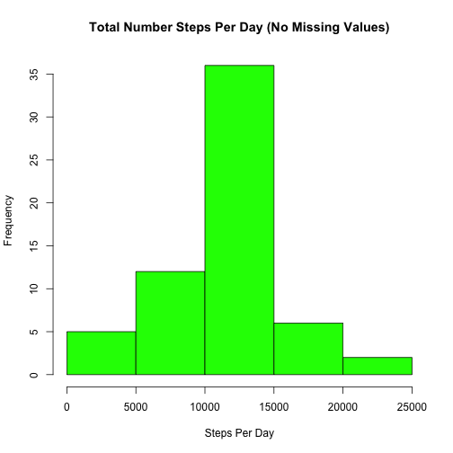

```r
totalStepsDateComplete <- aggregate(steps ~ date, data = activityDataComplete,
    sum)
hist(totalStepsDateComplete$steps, col = "green", main = "Total Number Steps Per Day (No Missing Values)",
    xlab = "Steps Per Day")
```

```r
meanStepsDayComplete <- mean(totalStepsDateComplete$steps)
medianStepsDayComplete <- median(totalStepsDateComplete$steps)
```

The Mean value remains 1.0766 × 10<sup>4</sup> due to the strategy of using mean values for replacement. The Median value has become 1.0766 × 10<sup>4</sup> due to the mean value inserted as an actual value.

## Are there differences in activity patterns between weekdays and weekends?

### 1. A new factor column indicating whether a given date is a “weekday” or a “weekend”.

```r
activityDataCompleteDay <- activityDataComplete
activityDataCompleteDay$day <- weekdays(as.Date(activityDataCompleteDay$date)) %in%
    c("Saturday", "Sunday")
activityDataCompleteDay$day <- ifelse(activityDataCompleteDay$day, "weekend",
    "weekday")
```

### 2. Performs preprocessing of data to cacluate averages by interval and by weekday or weekend. The resulting panel plot demonstrates 5 minute intervals of the average total steps across all weekdays and weekends

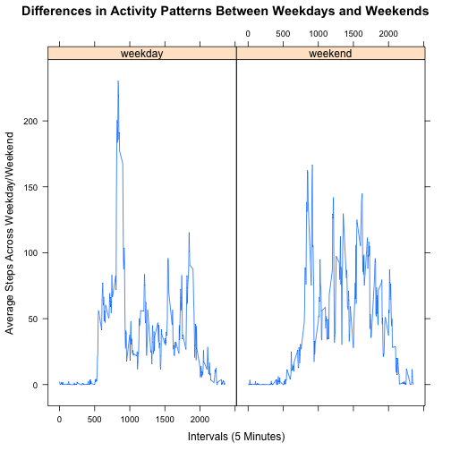

```r
avgStepsIntervalDay <- aggregate(steps ~ interval + day, activityDataCompleteDay,
    mean)
xyplot(steps ~ interval | factor(day), data = avgStepsIntervalDay, xlab = "Intervals (5 Minutes)",
    ylab = "Average Steps Across Weekday/Weekend", main = "Differences in Activity Patterns Between Weekdays and Weekends",
    type = "l")
```